# 第十組：社群媒體期末報告

## 5/04、5/20、5/24字詞統計圖

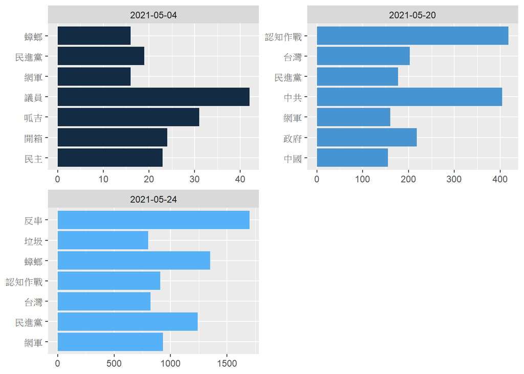

```r
g_tokens_by_date <- data_select %>% count(artDate, word, sort = TRUE)

plot_merge <- g_tokens_by_date %>%
  filter(artDate == as.Date("2021-05-04") |
         artDate == as.Date("2021-05-20") |
         artDate == as.Date("2021-05-24")) %>%
  group_by(artDate) %>%
  top_n(7, n) %>%
  ungroup() %>%
  mutate(word = reorder(word, n)) %>%
  ggplot(aes(x=word, y=n, fill = artDate)) +
  geom_col(show.legend = FALSE) +
  labs(x = NULL, y = NULL) +
  facet_wrap(~artDate, scales="free", ncol = 2) +
  coord_flip()
plot_merge
```

## 觀察出現在’林瑋豐’附近的詞彙

林瑋豐簡介: 林瑋豐原先任職於YouTube眼球中央電視台頻道的劇本作者，並與任職民進黨網路社群中心副主任的楊敏為夫妻關係，日前林瑋豐在臉書上表示，ＰＴＴ有許多帳號在洗版，鼓吹民眾移除或封鎖疾管署ＬＩＮＥ帳號「疾管家」，被網友揪出整起事件就是由他一人自導自演，在事情爆發後，他本人道歉並表示自己是在惡搞反串，但仍被鄉民們檢舉違反國安法假訊息。

```r
ngram_11 <- function(t) {
  lapply(t, function(x) {
    tokens <- segment(x, jieba_tokenizer)
    ngram <- ngrams(tokens, 11)
    ngram <- lapply(ngram, paste, collapse = " ")
    unlist(ngram)
  })
}

data_army <- MetaData %>%
  select(artUrl, sentence) %>%
  unnest_tokens(word, sentence, token = customized_tokenizer)

data_army= data_army %>%  filter(data_army$word == "網軍"|!str_detect(word, regex("[0-9a-zA-Z]")))

w = data_army %>% group_by(artUrl) %>% summarize(sentence = paste(word,collapse = ""))

g_ngram_11 <- w %>%
  select(artUrl, sentence) %>%
  unnest_tokens(ngram, sentence, token = ngram_11)

g_ngrams_11_separated <- g_ngram_11 %>%
  separate(ngram, paste0("word", c(1:11),sep=""), sep = " ")
```

```r
g_check_words <- g_ngrams_11_separated %>%
  filter(word6 == "林瑋豐")
```

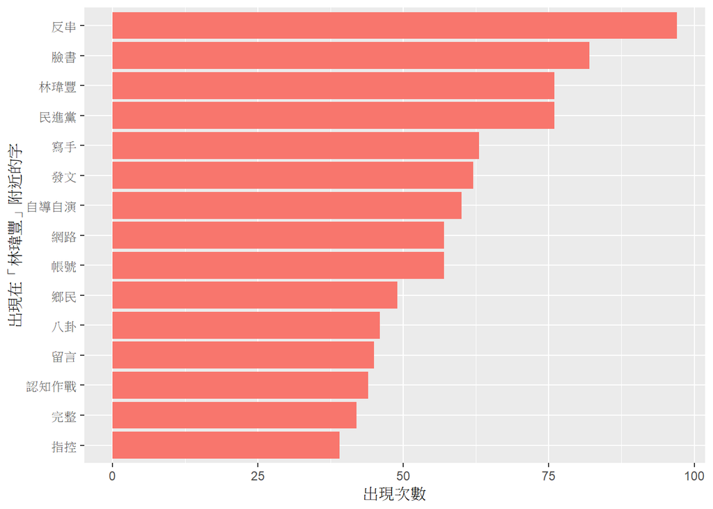

```r
g_check_words_count <- g_check_words %>%
  melt(id.vars = "artUrl", measure.vars = paste0("word", c(1:11),sep="")) %>%
  rename(word=value) %>%
  filter(variable!="word6") %>%
  filter(!(word %in% stop_words), nchar(word)>1) %>%
  count(word, sort = TRUE)
g_check_words_count %>%
  arrange(desc(abs(n))) %>%
  head(15) %>%
  mutate(word = reorder(word, n)) %>%
  ggplot(aes(word, n, fill = n > 0)) +
  geom_col(show.legend = FALSE) +
  xlab("出現在「林瑋豐」附近的字") +
  ylab("出現次數") +
  coord_flip()
```

## 字詞關聯圖

```r
g_words_by_art <- data_select %>%
  count(artUrl, word, sort = TRUE)
g_word_pairs <- g_words_by_art %>%
  pairwise_count(word, artUrl, sort = TRUE)
g_word_cors <- g_words_by_art %>%
  group_by(word) %>%
  filter(n() >= 20) %>%
  pairwise_cor(word, artUrl, sort = TRUE)
```

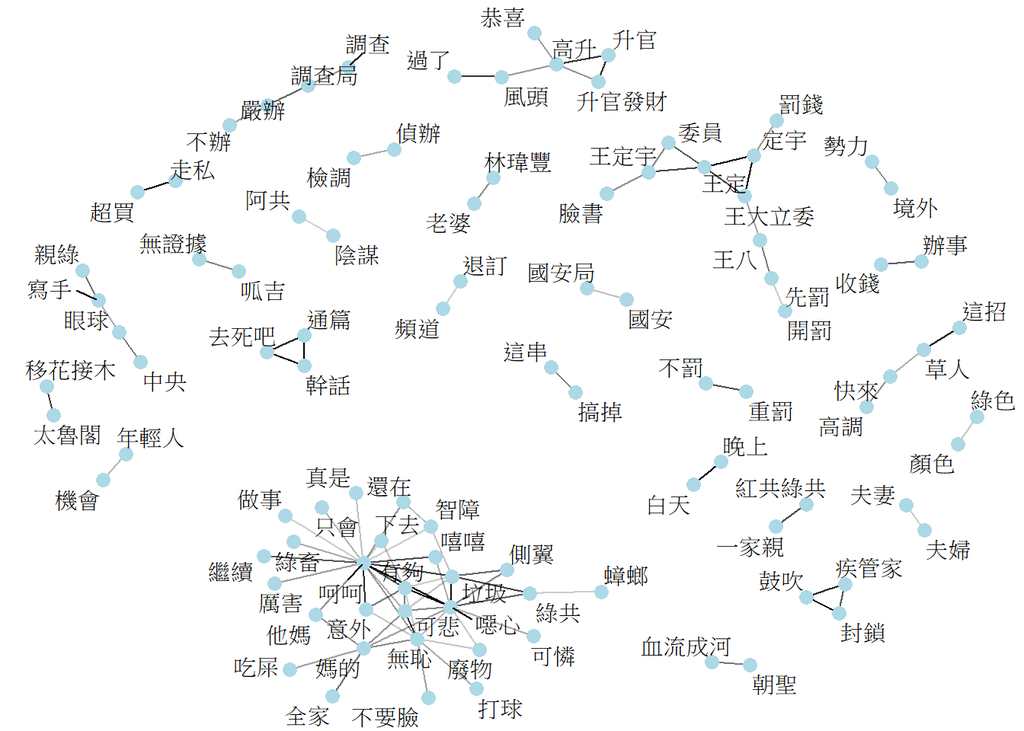

```r
threshold <- 0.6 #手動調參
remove_words <- g_word_cors %>%
                filter(correlation>threshold) %>%
                .$item1 %>%
                unique()
set.seed(2017)
g_word_cors_new <- g_word_cors %>%
                filter(!(item1 %in% remove_words|item2 %in% remove_words))

g_word_cors_new %>%
  filter(correlation > .474) %>%
  graph_from_data_frame() %>%
  ggraph(layout = "fr") +
  geom_edge_link(aes(edge_alpha = correlation), show.legend = FALSE) +
  geom_node_point(color = "lightblue", size = 3) +
  geom_node_text(aes(label = name), repel = TRUE) +
  theme_void()
```

```r
sentiment_count = data_select %>%
  select(artDate,word) %>%
  inner_join(LIWC) %>%
  group_by(artDate,sentiment) %>%
  summarise(count=n())
range(sentiment_count$artDate)
```

```
## [1] "2021-05-01" "2021-05-28"
```

## 5月正負情緒折線圖

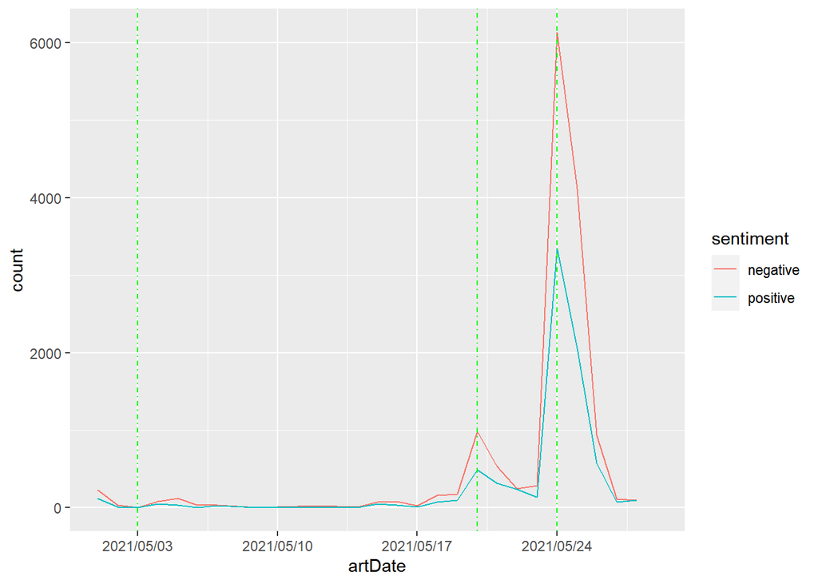

```r
sentiment_count %>%
  ggplot()+
  geom_line(aes(x=artDate,y=count,colour=sentiment))+

  scale_x_date(labels = date_format("%Y/%m/%d"),
               limits = as.Date(c('2021-05-01','2021-05-29'))
               )+
  # 加上標示日期的線
  geom_vline(aes(xintercept = as.numeric(artDate[which(sentiment_count$artDate == as.Date('2021-05-03'))
[1]])),colour = "green",linetype=4) +
  # 加上標示日期的線
  geom_vline(aes(xintercept = as.numeric(artDate[which(sentiment_count$artDate == as.Date('2021-05-20'))
[1]])),colour = "green",linetype=4) +
  # 加上標示日期的線
  geom_vline(aes(xintercept = as.numeric(artDate[which(sentiment_count$artDate == as.Date('2021-05-24'))
[1]])),colour = "green",linetype=4)
```

## 5月正負情緒比例折線圖

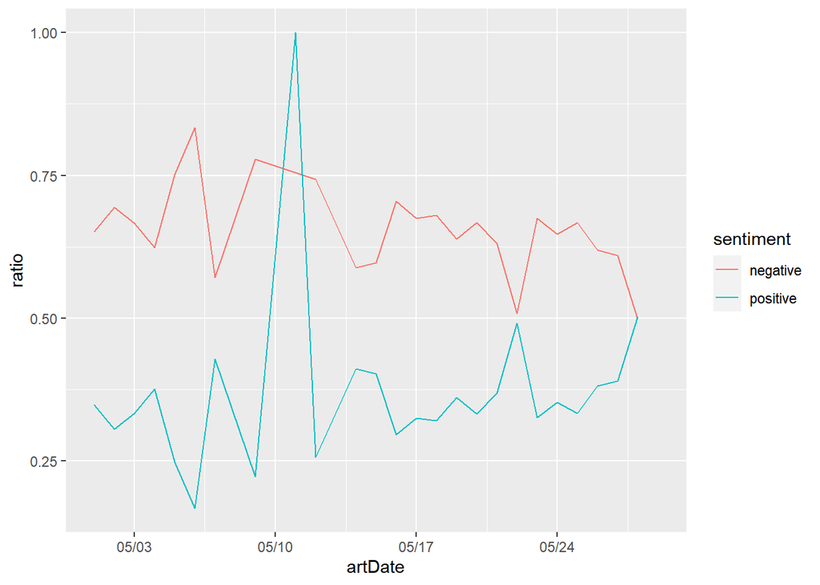

```r
sentiment_count %>%
  # 標準化的部分
  group_by(artDate) %>%
  mutate(ratio = count/sum(count)) %>%
  # 畫圖的部分
  ggplot()+
  geom_line(aes(x=artDate,y=ratio,colour=sentiment))+
  scale_x_date(labels = date_format("%m/%d"),
               limits = as.Date(c('2021-05-01','2021-05-29'))
               )
```

## 5/24正負情緒折線圖

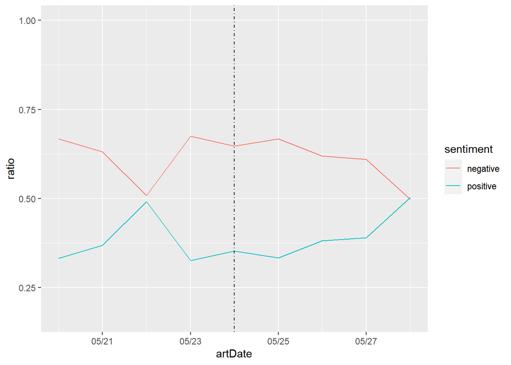

```r
sentiment_count %>%  filter(artDate<=as.Date("2021-05-29",format="%Y-%m-%d"))%>%
  group_by(artDate) %>%
  mutate(ratio = count/sum(count)) %>%
  ggplot()+
  geom_line(aes(x=artDate,y=ratio,colour=sentiment))+
  scale_x_date(labels = date_format("%m/%d"),
               limits = as.Date(c('2021-05-20','2021-005-29'))
               )+
  geom_vline(aes(xintercept = as.integer(as.Date("2021-05-24",format="%Y-%m-%d"))), col = "black",linetype=4)
```

## 5/24文字雲 (詞頻>200)

```r
# 畫出文字雲
 word_count  %>%
  filter(artDate == as.Date('2021-05-24')) %>%
  select(word,count) %>%
  group_by(word) %>%
  summarise(count = sum(count)) %>%
  arrange(desc(count)) %>%
  filter(count>200) %>%   # 過濾出現太少次的字
  wordcloud2()
```

[interactive chart not shown]

```r
# sentiment_sum:word,sentiment,sum
sentiment_sum <-
  word_count %>%
   filter(artDate == as.Date('2021-05-24')) %>%
    inner_join(LIWC) %>%
    group_by(word,sentiment) %>%
  summarise(
    sum = sum(count)
  ) %>%
  arrange(desc(sum)) %>%
  data.frame()
```

## 正負情緒貢獻圖

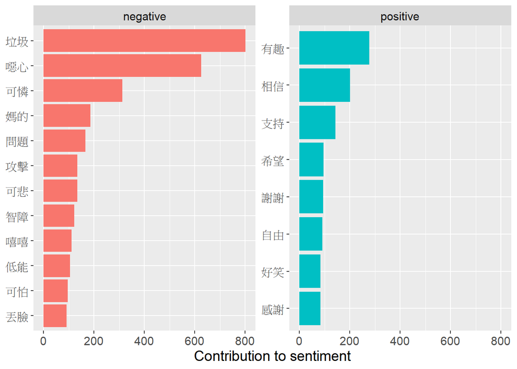

```r
sentiment_sum %>%
  top_n(20,wt = sum) %>%
  mutate(word = reorder(word, sum)) %>%
  ggplot(aes(word, sum, fill = sentiment)) +
  geom_col(show.legend = FALSE) +
  facet_wrap(~sentiment, scales = "free_y") +
  labs(y = "Contribution to sentiment",
       x = NULL) +
  theme(text=element_text(size=14))+
  coord_flip()
```

## 正負情緒文字雲(各取前50字)

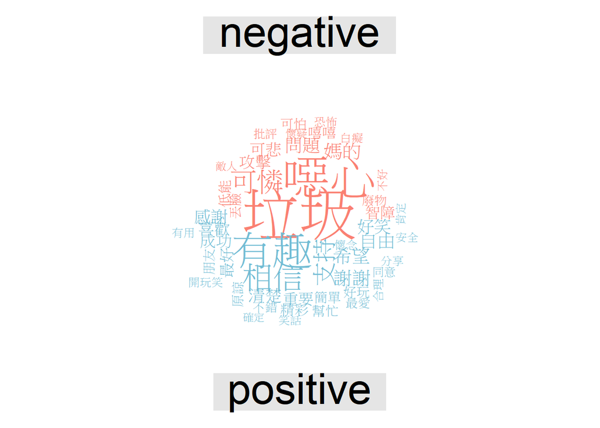

```r
sentiment_sum %>%
  acast(word ~ sentiment, value.var = "sum", fill = 0) %>%
  comparison.cloud(
    colors = c("salmon", "#72bcd4"), # positive negative
                   max.words = 50)
```

```r
article_type =
  data_select %>%
  inner_join(LIWC) %>%
  group_by(artUrl,sentiment) %>%
  summarise(count=n()) %>%
  spread(sentiment,count,fill = 0) %>% # 把正負面情緒展開，缺值補0
  mutate(type = case_when(positive > negative ~ "positive",
                             TRUE ~ "negative")) %>%
  data.frame()
# 看一下正負比例的文章各有幾篇
article_type %>%
  group_by(type) %>%
  summarise(count = n())
```

```
## # A tibble: 2 x 2
##   type     count
##   <chr>    <int>
## 1 negative   497
## 2 positive   196
```

## 5月的正負情緒文章比例圖

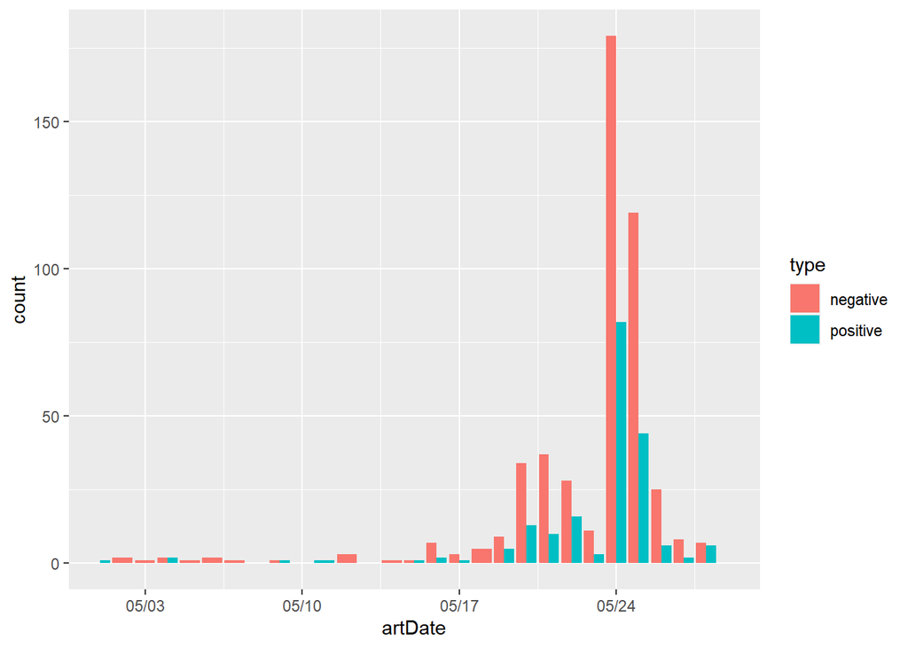

```r
article_type_date = left_join(article_type[,c("artUrl", "type")], MetaData[,c("artUrl", "artDate")], by = "artUrl")
article_type_date$artDate = as.Date(article_type_date$artDate,format="%Y/%m/%d")

article_type_date %>%
  group_by(artDate,type) %>%
  summarise(count = n()) %>%
  ggplot(aes(x = artDate, y = count, fill = type)) +
  geom_bar(stat = "identity", position = "dodge")+
  scale_x_date(labels = date_format("%m/%d"),
               limits = as.Date(c('2021-05-01','2021-05-29'))
               )
```

```r
# 格式化日期欄位
MToken$artDate= MToken$artDate %>% as.Date("%Y/%m/%d")



# 過濾特殊字元
data_select_a = MToken %>%
  filter(!grepl('[[:punct:]]',word)) %>% # 去標點符號
  filter(!grepl("['^0-9a-z']",word)) %>% # 去英文、數字
  filter(nchar(.$word)>1)


# 算每天不同字的詞頻
# word_count:artDate,word,count
tokens <- data_select_a %>%
  select(artUrl,word) %>%
  group_by(artUrl,word) %>%
  summarise(count=n()) %>%  # 算字詞單篇總數用summarise
   # 過濾出現太少次的字
  arrange(desc(count))
dtm <-tokens %>% cast_dtm(artUrl, word, count)
dtm
```

```
## <<DocumentTermMatrix (documents: 716, terms: 11505)>>
## Non-/sparse entries: 38281/8199299
## Sparsity           : 100%
## Maximal term length: 8
## Weighting          : term frequency (tf)
```

```r
inspect(dtm[1:10,1:10])
```

```
## <<DocumentTermMatrix (documents: 10, terms: 10)>>
## Non-/sparse entries: 38/62
## Sparsity           : 62%
## Maximal term length: 4
## Weighting          : term frequency (tf)
## Sample             :
##                                                           Terms
## Docs                                                       林瑋豐 肥肥 阿伯
##   https://www.ptt.cc/bbs/Gossiping/M.1621540161.A.405.html      0    0    0
##   https://www.ptt.cc/bbs/Gossiping/M.1621572487.A.59C.html      0    0    0
##   https://www.ptt.cc/bbs/Gossiping/M.1621687845.A.8D8.html      0    0    0
##   https://www.ptt.cc/bbs/Gossiping/M.1621768043.A.BEC.html      0   24   20
##   https://www.ptt.cc/bbs/Gossiping/M.1621857669.A.025.html      3    0    0
##   https://www.ptt.cc/bbs/Gossiping/M.1621879761.A.AFA.html      0    0    0
##   https://www.ptt.cc/bbs/Gossiping/M.1621895979.A.0DC.html      0    0    0
##   https://www.ptt.cc/bbs/Gossiping/M.1621919105.A.780.html      0    0    0
##   https://www.ptt.cc/bbs/Gossiping/M.1621930555.A.3E2.html     18    0    0
##   https://www.ptt.cc/bbs/Gossiping/M.1621956282.A.6B8.html     27    0    0
##                                                           Terms
## Docs                                                       政府 柯文哲 帳號
##   https://www.ptt.cc/bbs/Gossiping/M.1621540161.A.405.html    8      1    0
##   https://www.ptt.cc/bbs/Gossiping/M.1621572487.A.59C.html    0      0    0
##   https://www.ptt.cc/bbs/Gossiping/M.1621687845.A.8D8.html    2     44    0
##   https://www.ptt.cc/bbs/Gossiping/M.1621768043.A.BEC.html    1      0    0
##   https://www.ptt.cc/bbs/Gossiping/M.1621857669.A.025.html    9      0    0
##   https://www.ptt.cc/bbs/Gossiping/M.1621879761.A.AFA.html    1      0   24
##   https://www.ptt.cc/bbs/Gossiping/M.1621895979.A.0DC.html    1      0    0
##   https://www.ptt.cc/bbs/Gossiping/M.1621919105.A.780.html   32      0    1
##   https://www.ptt.cc/bbs/Gossiping/M.1621930555.A.3E2.html    0      0    7
##   https://www.ptt.cc/bbs/Gossiping/M.1621956282.A.6B8.html    0      0    4
##                                                           Terms
## Docs                                                       資訊 監督 網軍
##   https://www.ptt.cc/bbs/Gossiping/M.1621540161.A.405.html    1    0    1
##   https://www.ptt.cc/bbs/Gossiping/M.1621572487.A.59C.html   23    0    2
##   https://www.ptt.cc/bbs/Gossiping/M.1621687845.A.8D8.html    0    0    1
##   https://www.ptt.cc/bbs/Gossiping/M.1621768043.A.BEC.html    0    0    0
##   https://www.ptt.cc/bbs/Gossiping/M.1621857669.A.025.html    0    0    0
##   https://www.ptt.cc/bbs/Gossiping/M.1621879761.A.AFA.html    2    0    1
##   https://www.ptt.cc/bbs/Gossiping/M.1621895979.A.0DC.html    0    0    1
##   https://www.ptt.cc/bbs/Gossiping/M.1621919105.A.780.html    2   22   26
##   https://www.ptt.cc/bbs/Gossiping/M.1621930555.A.3E2.html    2    0    0
##   https://www.ptt.cc/bbs/Gossiping/M.1621956282.A.6B8.html    1    0    0
##                                                           Terms
## Docs                                                       認知作戰
##   https://www.ptt.cc/bbs/Gossiping/M.1621540161.A.405.html       17
##   https://www.ptt.cc/bbs/Gossiping/M.1621572487.A.59C.html        1
##   https://www.ptt.cc/bbs/Gossiping/M.1621687845.A.8D8.html        1
##   https://www.ptt.cc/bbs/Gossiping/M.1621768043.A.BEC.html        5
##   https://www.ptt.cc/bbs/Gossiping/M.1621857669.A.025.html        0
##   https://www.ptt.cc/bbs/Gossiping/M.1621879761.A.AFA.html        1
##   https://www.ptt.cc/bbs/Gossiping/M.1621895979.A.0DC.html        0
##   https://www.ptt.cc/bbs/Gossiping/M.1621919105.A.780.html        0
##   https://www.ptt.cc/bbs/Gossiping/M.1621930555.A.3E2.html        6
##   https://www.ptt.cc/bbs/Gossiping/M.1621956282.A.6B8.html        6
```

##LDA

```r
lda <- LDA(dtm, k = 2, control = list(seed = 2021))
```

```r
topics_words <- tidy(lda, matrix = "beta") # 注意，在tidy function裡面要使用"beta"來取出Phi矩陣。
colnames(topics_words) <- c("topic", "term", "phi")
topics_words
```

```
## # A tibble: 23,010 x 3
##    topic term        phi
##    <int> <chr>     <dbl>
##  1     1 柯文哲 2.92e- 3
##  2     2 柯文哲 2.03e- 4
##  3     1 政府   8.80e- 3
##  4     2 政府   2.92e- 3
##  5     1 林瑋豐 2.69e- 3
##  6     2 林瑋豐 1.95e- 2
##  7     1 網軍   1.91e- 2
##  8     2 網軍   3.89e- 3
##  9     1 肥肥   5.59e-11
## 10     2 肥肥   1.00e- 3
## # ... with 23,000 more rows
```

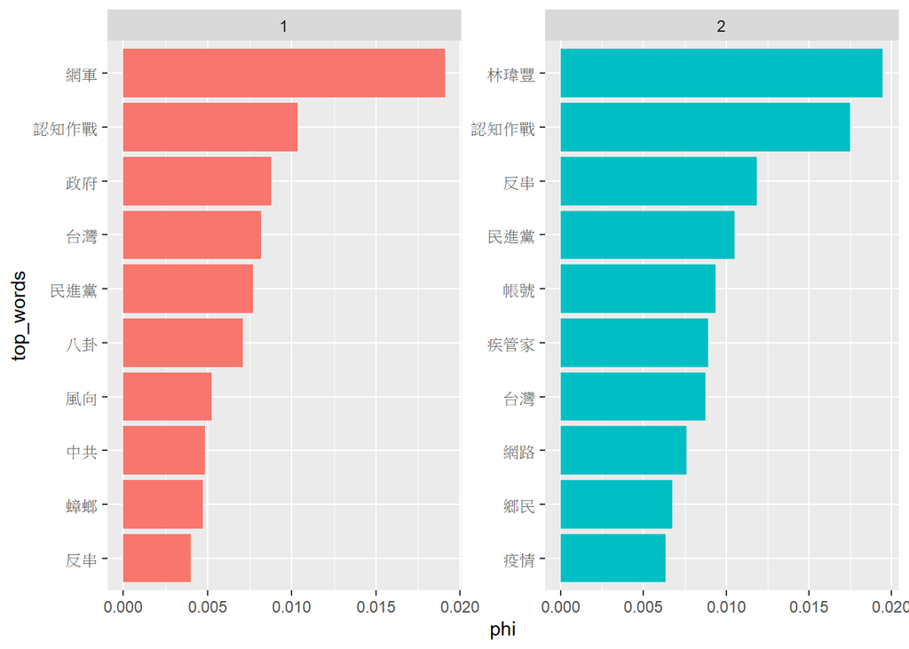

```r
topics_words %>%
  group_by(topic) %>%
  top_n(10, phi) %>%
  ungroup() %>%
  mutate(top_words = reorder_within(term,phi,topic)) %>%
  ggplot(aes(x = top_words, y = phi, fill = as.factor(topic))) +
  geom_col(show.legend = FALSE) +
  facet_wrap(~ topic, scales = "free") +
  coord_flip() +
  scale_x_reordered()
```

## 尋找最佳主題數

```r
ldas = c()
topics = c(2,3,4,6,10,15)
for(topic in topics){
  start_time <- Sys.time()
  lda <- LDA(dtm, k = topic, control = list(seed = 2021))
  ldas =c(ldas,lda)
 print(paste(topic ,paste("topic(s) and use time is ", Sys.time() -start_time)))
save(ldas,file = "ldas_result.rdata") # 將模型輸出成檔案
}
```

```
## [1] "2 topic(s) and use time is  2.23878192901611"
## [1] "3 topic(s) and use time is  4.16598510742188"
## [1] "4 topic(s) and use time is  4.9470419883728"
## [1] "6 topic(s) and use time is  8.26025199890137"
## [1] "10 topic(s) and use time is  13.5972487926483"
## [1] "15 topic(s) and use time is  26.145681142807"
```

```r
#("ldas_result.rdata")
```

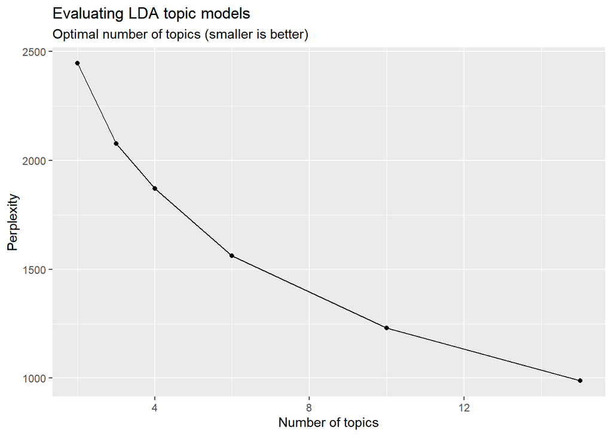

```r
topics = c(2,3,4,6,10,15)
data_frame(k = topics, perplex = map_dbl(ldas, topicmodels::perplexity)) %>%
  ggplot(aes(k, perplex)) +
  geom_point() +
  geom_line() +
  labs(title = "Evaluating LDA topic models",
       subtitle = "Optimal number of topics (smaller is better)",
       x = "Number of topics",
       y = "Perplexity")
```

```r
topicmodels_json_ldavis <- function(fitted, doc_term){
    require(LDAvis)
    require(slam)

    ###以下function 用來解決，主題數多會出現NA的問題
    ### 參考 https://github.com/cpsievert/LDAvis/commit/c7234d71168b1e946a361bc00593bc5c4bf8e57e
    ls_LDA = function (phi){
      jensenShannon <- function(x, y) {
        m <- 0.5 * (x + y)
        lhs <- ifelse(x == 0, 0, x * (log(x) - log(m+1e-16)))
        rhs <- ifelse(y == 0, 0, y * (log(y) - log(m+1e-16)))
        0.5 * sum(lhs) + 0.5 * sum(rhs)
      }
      dist.mat <- proxy::dist(x = phi, method = jensenShannon)
      pca.fit <- stats::cmdscale(dist.mat, k = 2)
      data.frame(x = pca.fit[, 1], y = pca.fit[, 2])
    }

      # Find required quantities
      phi <- as.matrix(posterior(fitted)$terms)
      theta <- as.matrix(posterior(fitted)$topics)
      vocab <- colnames(phi)
      term_freq <- slam::col_sums(doc_term)

      # Convert to json
      json_lda <- LDAvis::createJSON(phi = phi, theta = theta,
                                     vocab = vocab,
                                     doc.length = as.vector(table(doc_term$i)),
                                     term.frequency = term_freq, mds.method = ls_LDA)

      return(json_lda)
}
```

```r
the_lda = ldas[[2]]
json_res <- topicmodels_json_ldavis(the_lda,dtm)
#serVis(json_res,open.browser = T)
```

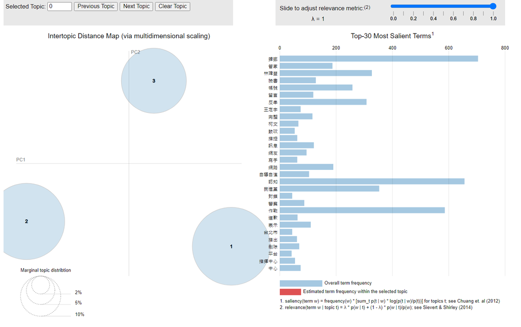

#也嘗試過分4個topic(但我們認為第2還有4的主題太過相近，因此選擇分三群)

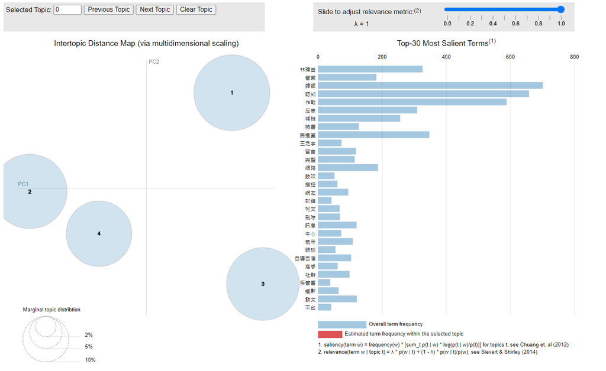

## LDA分析

```r
the_lda = ldas[[2]] ## 選定topic 為 3 的結果
```

```r
topics_words <- tidy(the_lda, matrix = "beta") # 注意，在tidy function裡面要使用"beta"來取出Phi矩陣。
colnames(topics_words) <- c("topic", "term", "phi")
topics_words %>% arrange(desc(phi)) %>% head(10)
```

```
## # A tibble: 10 x 3
##    topic term        phi
##    <int> <chr>     <dbl>
##  1     2 林瑋豐   0.0257
##  2     3 認知作戰 0.0226
##  3     3 網軍     0.0168
##  4     1 網軍     0.0144
##  5     2 反串     0.0141
##  6     3 台灣     0.0136
##  7     2 民進黨   0.0131
##  8     2 認知作戰 0.0130
##  9     2 帳號     0.0127
## 10     2 疾管家   0.0124
```

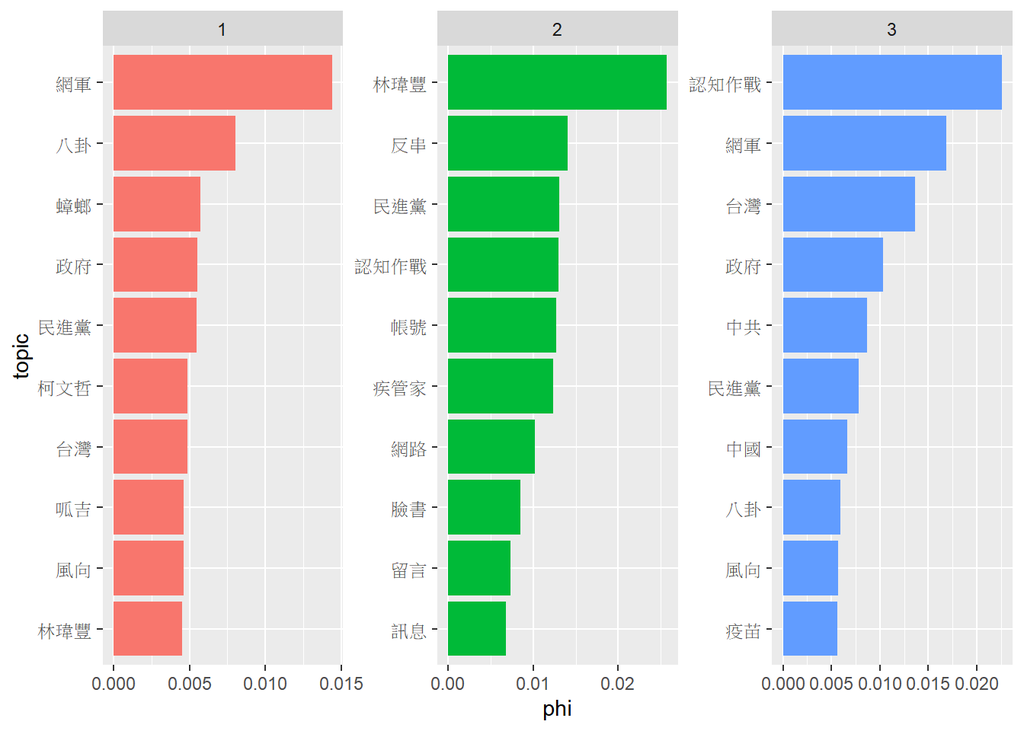

```r
topics_words %>%
  group_by(topic) %>%
  top_n(10, phi) %>%
  ungroup() %>%
  ggplot(aes(x = reorder_within(term,phi,topic), y = phi, fill = as.factor(topic))) +
  geom_col(show.legend = FALSE) +
  facet_wrap(~ topic, scales = "free") +
  coord_flip() +
  xlab("topic")+
  scale_x_reordered()
```

##主題命名

```r
topics_name = c("鄉民討論網軍","鄉民起底林瑋豐的PTT帳號","鄉民認為認知作戰是網軍自導自演")
```

## Document主題分布

```r
# for every document we have a probability distribution of its contained topics
tmResult <- posterior(the_lda)
doc_pro <- tmResult$topics
n_distinct(MetaData$artDate)
```

```
## [1] 26
```

```r
document_topics <- doc_pro[MetaData$artUrl,]
document_topics_df =data.frame(document_topics)
colnames(document_topics_df) = topics_name
rownames(document_topics_df) = NULL
news_topic = cbind(MetaData,document_topics_df)
```

```r
news_topic %>%
  arrange(desc('鄉民討論網軍')) %>% head(10)
```

```
##                                           artTitle    artDate  artTime
##  1: Re:[新聞]PTT剩1種顏色網軍？呱吉親爆內幕　3層「 2021/05/01 04:01:33
##  2: Re:[新聞]PTT剩1種顏色網軍？呱吉親爆內幕　3層「 2021/05/01 07:09:55
##  3: Re:[新聞]PTT剩1種顏色網軍？呱吉親爆內幕　3層「 2021/05/01 07:23:41
##  4: Re:[新聞]PTT剩1種顏色網軍？呱吉親爆內幕　3層「 2021/05/01 07:27:51
##  5: Re:[新聞]PTT剩1種顏色網軍？呱吉親爆內幕　3層「 2021/05/01 08:04:52
##  6: Re:[新聞]PTT剩1種顏色網軍？呱吉親爆內幕　3層「 2021/05/01 08:17:13
##  7: Re:[新聞]PTT剩1種顏色網軍？呱吉親爆內幕　3層「 2021/05/01 08:46:39
##  8: Re:[新聞]PTT剩1種顏色網軍？呱吉親爆內幕　3層「 2021/05/01 09:00:27
##  9: Re:[新聞]PTT剩1種顏色網軍？呱吉親爆內幕　3層「 2021/05/01 09:54:12
## 10: Re:[新聞]PTT剩1種顏色網軍？呱吉親爆內幕　3層「 2021/05/01 12:07:49
##                                                       artUrl    artPoster
##  1: https://www.ptt.cc/bbs/Gossiping/M.1619841695.A.1E4.html       l42857
##  2: https://www.ptt.cc/bbs/Gossiping/M.1619852997.A.8EF.html cary4A240022
##  3: https://www.ptt.cc/bbs/Gossiping/M.1619853823.A.AF5.html         chal
```

[output cut: 40 more lines]

[figure not shown]

```r
news_topic %>%
  select(-c("commentNum","push","boo")) %>%
  mutate(artDate = as.Date(artDate)) %>%
 group_by(artDate = format(artDate,'%Y%m%d')) %>%
  summarise_if(is.numeric, sum, na.rm = TRUE) %>%
  melt(id.vars = "artDate")%>%
  ggplot( aes(x=artDate, y=value, fill=variable)) +
  geom_bar(stat = "identity") + ylab("value") +
  scale_fill_manual(values=mycolors[c(1,5,8,12)])+
  theme(axis.text.x = element_text(angle = 90, hjust = 1))
```

#這個月的總表

[figure not shown]

```r
news_topic %>%
  select(-c("commentNum","push","boo")) %>%
  mutate(artDate = as.Date(artDate)) %>%
 group_by(artDate = format(artDate,'%Y%m')) %>%
  summarise_if(is.numeric, sum, na.rm = TRUE) %>%
  melt(id.vars = "artDate")%>%
  ggplot( aes(x=artDate, y=value, fill=variable)) +
  geom_bar(stat = "identity") + ylab("value") +
  scale_fill_manual(values=mycolors[c(1,5,8,12)])+
  theme(axis.text.x = element_text(angle = 90, hjust = 1))
```